# STAT3064: Assigmment 1

1. 1. Why is it important to describe the mathematical model we want to simulate from and why should one not automatically choose the Gaussian model for a simulation?

      It is important to describe the mathematical model we want to simulate from because we will require to use that model to estimate/predict trends and patterns if we find that the model that has been described demonstrates simulations which closely match the observed experimental results.

      When selecting a mathematical model to perform simulations from, one must not automatically choose a Gaussian model to analyse, as it is unlikely that all experimental contexts will be producing trends which can be accurately described by a Gaussian Model. Examples of this may include a growth/decay context which may be better suited by a exponential model, or current-day COVID cases being better represented by a logistical model.
   2. Give two reasons why simulations should be reproducible.
      1. Investigation / Research may be progeressed in an efficient manner, and the reproducibility will allow for the simulation to be re-used or compared with different simulations to evaluate effectiveness of a model.
      2. To check and verify the validty of the simulations by an external party. This emerges from having the simulation in a reproducible state, with the relevant steps and assumptions documented, which can be critically examined to review validity.
   3. Give details of the variance calculation var($W_2$) for Example 4.2 similar to those for var($W_1$).

      var($W_2$) = var($n_2 ^T$*X*) = var($n_{21}$**X**$_1$ + $n_{22}$**X**$_2$)

      = $n_{21}^2$var(**X**$_1$) + $n_{22}^2$var(**X**$_2$) + 2$n_{21}n_{22}$ * cov(**X**$_1$, **X**$_2$)

      = 0.31$^2$ * 2.4 + 0.95$^2$ * 1 + 2 * 0.31 * 0.95 * (-0.5)

      = **0.84**
2. Consider the aircraft data with the logged variables as in Question 2 of Computer Lab 1. Divide the data into the three period groups. We are interested in comparing changes that occur over time.

   Setup working environment

```r
rm(list = ls())

if (!is.null(sessionInfo()$otherPkgs)) {
  invisible(
    lapply(paste0('package:', names(sessionInfo()$otherPkgs)),
           detach, character.only=TRUE, unload=TRUE)
  )
}

options(stringsAsFactors = FALSE)

library(ggplot2)
library(tidyverse)
```

```r
library(MASS)
```

```r
library(GGally)
```

```r
setwd('C:/Users/aliye/Documents/STAT3064/Assignment 1')

aircraft = read.csv('aircraft.csv')
```

1. Show smoothed histograms of logLength and logPower separately for the three periods. Comment on the shapes of the histograms and how the change over time affects this shape.

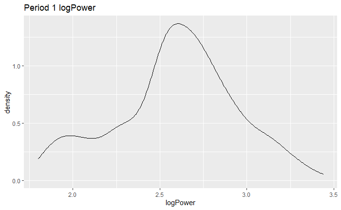

```r
logPower = log10(aircraft$Power)
logSpan = log10(aircraft$Span)
logLength = log10(aircraft$Length)
logWeight = log10(aircraft$Weight)
logSpeed = log10(aircraft$Speed)
logRange = log10(aircraft$Range)

Period = as.factor(aircraft$Period)

Year= aircraft$Year

log_aircraft = data.frame(Year, Period, logPower, logSpan, logLength, logWeight, logSpeed, logRange)

aircraft.per1 = filter( log_aircraft, Period == "1" )
aircraft.per2 = filter( log_aircraft, Period == "2" )
aircraft.per3 = filter( log_aircraft, Period == "3" )

# For Period == 1 #
ggplot( aircraft.per1, aes(logPower)  ) + geom_density() + ggtitle("Period 1 logPower")
```

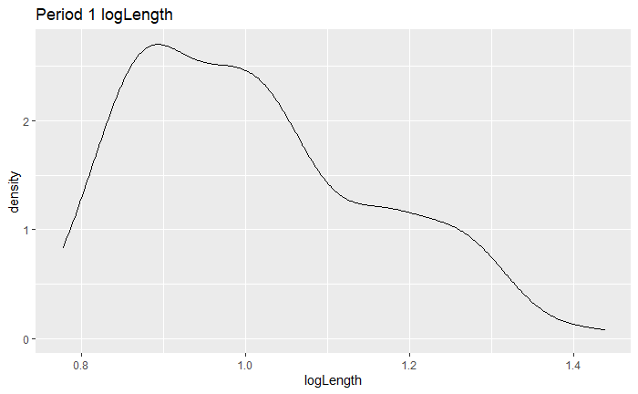

```r
ggplot( aircraft.per1, aes(logLength)  ) + geom_density() + ggtitle("Period 1 logLength")
```

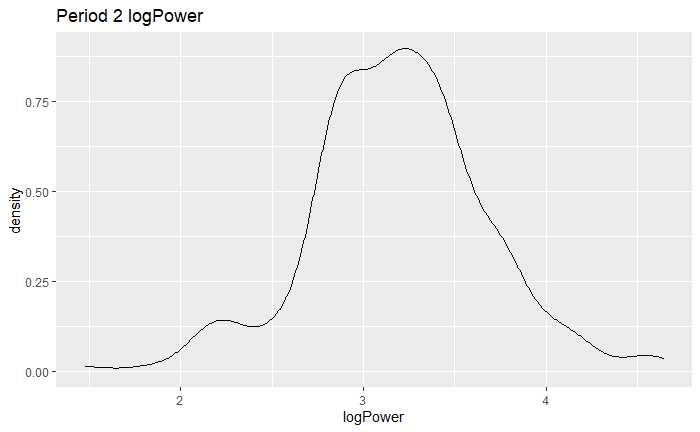

```r
# For Period == 2 #
ggplot( aircraft.per2, aes(logPower)  ) + geom_density() + ggtitle("Period 2 logPower")
```

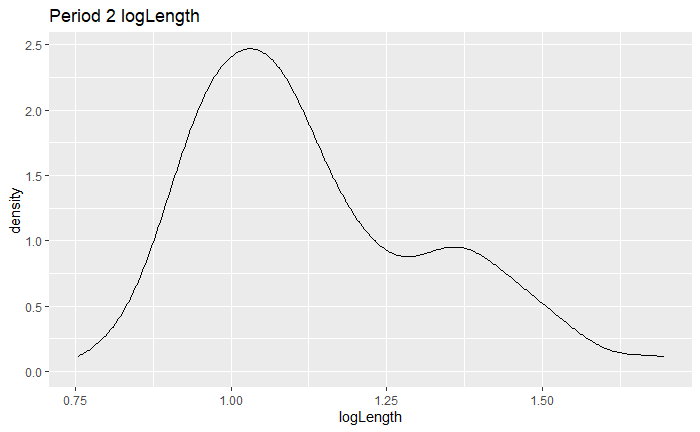

```r
ggplot( aircraft.per2, aes(logLength)  ) + geom_density() + ggtitle("Period 2 logLength")
```

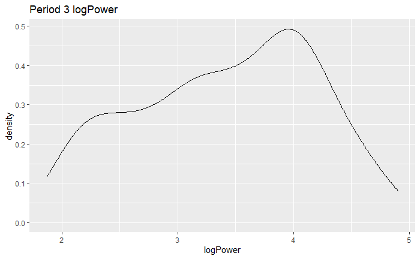

```r
# For Period == 3 #
ggplot( aircraft.per3, aes(logPower)  ) + geom_density() + ggtitle("Period 3 logPower")
```

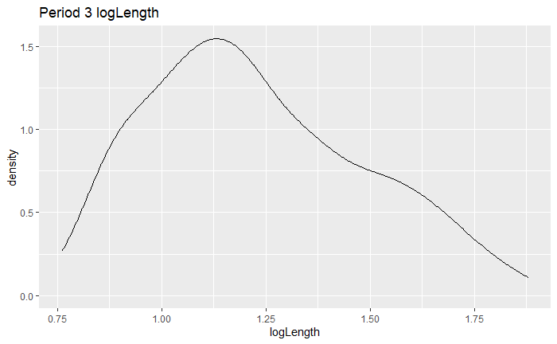

```r
ggplot( aircraft.per3, aes(logLength)  ) + geom_density() + ggtitle("Period 3 logLength")
```

```r
NA
NA
```

**Log** **Power** **Comments**

The logPower curves for the first two periods seem to be forming a relatively normal, non-skewed distribution, with definite peaks occurring at 2.6 and 3.3 respectively for Periods 1 and 2. For Period 3, the distribution seems to be relatively flattened, with a peak occuring at approximately 3.9, and the overall geometry of the curve appears to have skewed to the left.

**Log** **Length** **Comments**

The logLength curves for all the periods seem to be skewed to the right, with the peaks occuring at approximately 0.90, 1.05, and 1.13 respectively. Period 1 and 3 seem to be hinting at a second mode in the density of the data points, with Period 2 having a second mode visibly defined at approximately 1.35.

2. Construct contour plots of the 2D smoothed histograms of the pairs (logPower, logWeight) and (logSpeed, logLength). Describe the shapes of the density plots and discuss how they change over time.

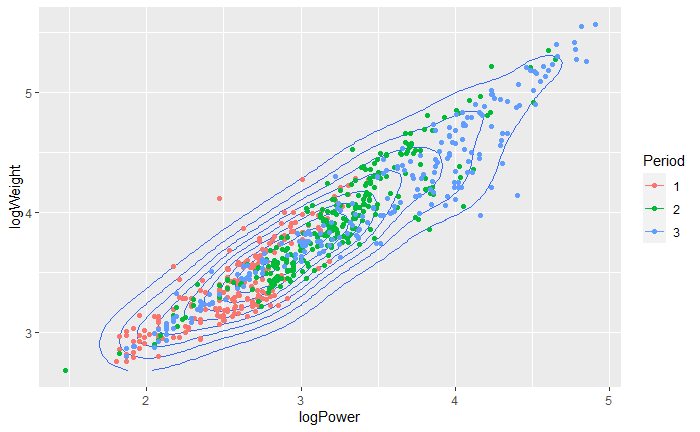

```r
ggplot( log_aircraft, aes( logPower, logWeight )) + geom_density_2d( ) + geom_point( aes( colour = Period))
```

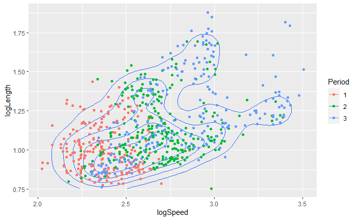

```r
ggplot( log_aircraft, aes( logSpeed, logLength )) + geom_density_2d( ) + geom_point( aes( colour = Period))
```

**Log** **Weight** **-** **Log** **Power** **Comments**

Through visual inspection of the above density plot, there seems to be a directly proportional relationship between logWeight and logPower. The overall contours indicate that the data is skewed towards the lower logPower-logWeight regions.

**Log** **Length** **-** **Log** **Speed** **Comments**

Through visual inspection of the above density plot, there doesn’t seem to be any definitive relationship between the data points, and therefore between the logSpeed and logLength variables. The contour lines show hint at the data points being more heavily concentrated around the region (logSpeed, logLength) -> (2.5, 0.9).

3. For which pair of variables would you expect the largest change in correlation or shape of their density over time and why?

I would expect the largest change in correlation or shape of density over time to occur between variables logPower and logWeight. This is mainly due to the expectation that as time progresses, modern technology would be able to develop machinery which would lead to a common trend of higher power and weight packages. Hence, in a statistical context, we would expect the correlation to increase between logPower and logWeight, as we progress from Periods 1-3.

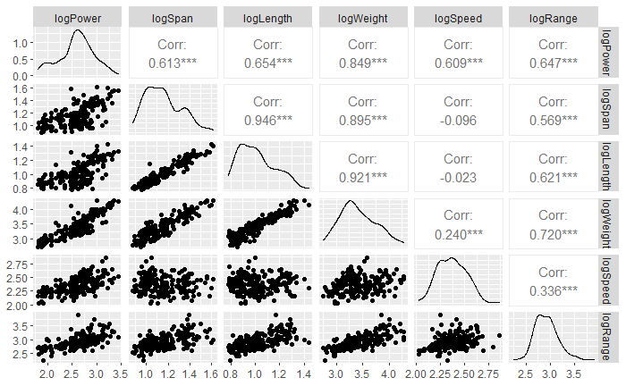

```r
ggpairs( aircraft.per1, columns = 3:8, progress = FALSE )
```

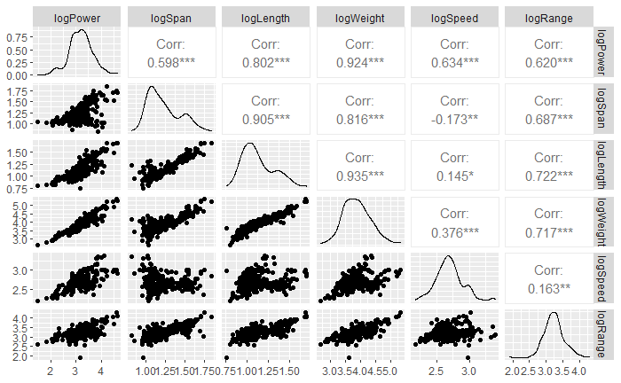

```r
ggpairs( aircraft.per2, columns = 3:8, progress = FALSE )
```

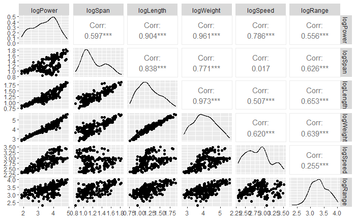

```r
ggpairs( aircraft.per3, columns = 3:8, progress = FALSE )
```

3. Consider the aircraft data of Q2 of this assignment.
1. Separately for each period, carry out a principal component analysis using prcomp based on the raw data.

```r
prc.per1 <- prcomp(aircraft.per1[3:8])
prc.per2 <- prcomp(aircraft.per2[3:8])
prc.per3 <- prcomp(aircraft.per3[3:8])

prc.per1
```

```
Standard deviations (1, .., p=6):
[1] 0.54121317 0.21189761 0.16332805 0.06481947 0.04282050 0.03400493

Rotation (n x k) = (6 x 6):
                PC1         PC2         PC3         PC4         PC5          PC6
logPower  0.6023445 -0.52495227  0.29433908 -0.50068246 -0.13855870 -0.071339185
logSpan   0.2480464  0.40547833  0.14450400  0.08786185 -0.71648259  0.481779927
logLength 0.2314834  0.32338440  0.08857805  0.18741528 -0.26911794 -0.852316218
logWeight 0.6172604  0.31854360  0.16972831  0.31721724  0.59379076  0.188408226
logSpeed  0.1123444 -0.59417244 -0.06942845  0.76786106 -0.19763566  0.029104377
logRange  0.3583823  0.03039818 -0.92250150 -0.12741855 -0.05815833  0.003341182
```

```r
prc.per2
```

```
Standard deviations (1, .., p=6):
[1] 0.73365449 0.27664901 0.18398492 0.07119554 0.04754417 0.03954359

Rotation (n x k) = (6 x 6):
                 PC1        PC2         PC3         PC4         PC5         PC6
logPower  -0.6304177 -0.4376049  0.03098939  0.63614276 -0.06269326 -0.03882048
logSpan   -0.2119693  0.4200196  0.27670129  0.13541076  0.21627457  0.79810914
logLength -0.2386678  0.2062956  0.18548549 -0.05077596  0.81399620 -0.44822641
logWeight -0.6209467  0.1229491  0.29218013 -0.59075644 -0.38607375 -0.12606871
logSpeed  -0.1316310 -0.6083592 -0.32859283 -0.47334841  0.36975954  0.37923382
logRange  -0.3126958  0.4520068 -0.83350388  0.03682695 -0.03049572 -0.02993745
```

```r
prc.per3
```

```
Standard deviations (1, .., p=6):
[1] 1.08281851 0.33181142 0.21518559 0.06604848 0.04787468 0.04150771

Rotation (n x k) = (6 x 6):
                 PC1        PC2         PC3         PC4         PC5         PC6
logPower  -0.7040925  0.3057378 -0.01113024 -0.62563798 -0.10243223 -0.09348250
logSpan   -0.1508836 -0.4672737 -0.29833491 -0.02723160 -0.63237979  0.51888340
logLength -0.2236956 -0.1816127 -0.14567553  0.34831652 -0.40132405 -0.78317965
logWeight -0.5962915 -0.2193689 -0.23948642  0.45059075  0.54941099  0.18459572
logSpeed  -0.2031599  0.5935210  0.35317257  0.52990063 -0.35577589  0.27268456
logRange  -0.1860395 -0.5047838  0.84116968 -0.05181172  0.01065492 -0.01477241
```

2. Show eigenvalue plots for each period. Interpret the results.

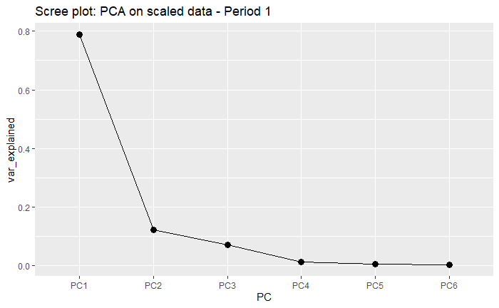

```r
var_explained_period1 <- data.frame(PC= paste0("PC",1:6), var_explained=(prc.per1$sdev)^2/sum((prc.per1$sdev)^2))
 ggplot(var_explained_period1,aes(x=PC,y=var_explained, group=1))+
  geom_point(size=3)+
  geom_line()+
  labs(title="Scree plot: PCA on scaled data - Period 1")
```

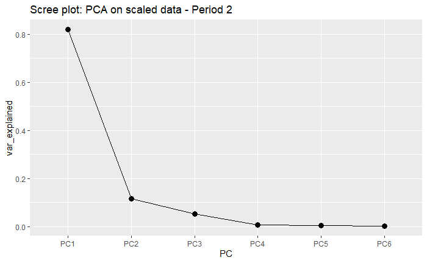

```r
var_explained_period2 <- data.frame(PC= paste0("PC",1:6), var_explained=(prc.per2$sdev)^2/sum((prc.per2$sdev)^2))
 ggplot(var_explained_period2,aes(x=PC,y=var_explained, group=1))+
  geom_point(size=3)+
  geom_line()+
  labs(title="Scree plot: PCA on scaled data - Period 2")
```

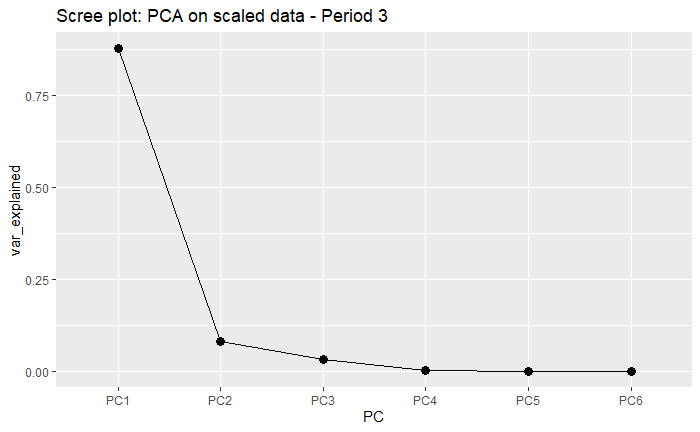

```r
var_explained_period3 <- data.frame(PC= paste0("PC",1:6), var_explained=(prc.per3$sdev)^2/sum((prc.per3$sdev)^2))
 ggplot(var_explained_period3,aes(x=PC,y=var_explained, group=1))+
  geom_point(size=3)+
  geom_line()+
  labs(title="Scree plot: PCA on scaled data - Period 3")
```

It is evident through the above that the factors 1 and 2 are the variables which are able to explain most of the variance seen in the data frames (approximately 90%), for all three periods. This means that the complexity of the overall problem can be condensed down to two factors (without losing extensive variability - <10%), instead of using all six variables.

3. Show score plots of the first two PCs for each period. Comment on the results.

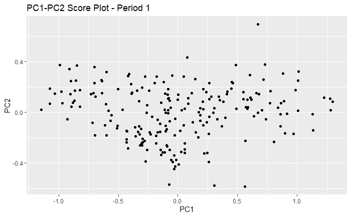

```r
df_out1 <- as.data.frame(prc.per1$x)
ggplot(df_out1,aes(x=PC1,y=PC2 ), xlim=c(-3,3))+geom_point()+
  labs(title="PC1-PC2 Score Plot - Period 1")
```

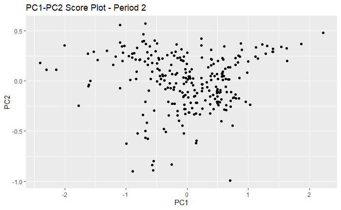

```r
df_out2 <- as.data.frame(prc.per2$x)
ggplot(df_out2,aes(x=PC1,y=PC2 ))+geom_point()+
  labs(title="PC1-PC2 Score Plot - Period 2")
```

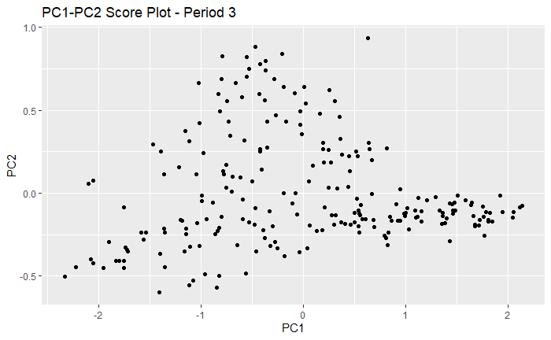

```r
df_out3 <- as.data.frame(prc.per3$x)
ggplot(df_out3,aes(x=PC1,y=PC2 ))+geom_point()+
  labs(title="PC1-PC2 Score Plot - Period 3")
```

Through visual inspection of the above plots, it can be seen that there is a greater concentration of scores towards the centre (0,0) in Periods 1 and 2, which would indicate the average point, with respect to PC1 and PC2, across all observations. This indicates that Period 3 is the time region to experience a larger degree of variability.

4. Which logged variable contributes most to PC1 for each period? Does this change across the three periods? Comment on the results.

```r
prc.per1$rotation
```

```
                PC1         PC2         PC3         PC4         PC5          PC6
logPower  0.6023445 -0.52495227  0.29433908 -0.50068246 -0.13855870 -0.071339185
logSpan   0.2480464  0.40547833  0.14450400  0.08786185 -0.71648259  0.481779927
logLength 0.2314834  0.32338440  0.08857805  0.18741528 -0.26911794 -0.852316218
logWeight 0.6172604  0.31854360  0.16972831  0.31721724  0.59379076  0.188408226
logSpeed  0.1123444 -0.59417244 -0.06942845  0.76786106 -0.19763566  0.029104377
logRange  0.3583823  0.03039818 -0.92250150 -0.12741855 -0.05815833  0.003341182
```

```r
prc.per2$rotation
```

```
                 PC1        PC2         PC3         PC4         PC5         PC6
logPower  -0.6304177 -0.4376049  0.03098939  0.63614276 -0.06269326 -0.03882048
logSpan   -0.2119693  0.4200196  0.27670129  0.13541076  0.21627457  0.79810914
logLength -0.2386678  0.2062956  0.18548549 -0.05077596  0.81399620 -0.44822641
logWeight -0.6209467  0.1229491  0.29218013 -0.59075644 -0.38607375 -0.12606871
logSpeed  -0.1316310 -0.6083592 -0.32859283 -0.47334841  0.36975954  0.37923382
logRange  -0.3126958  0.4520068 -0.83350388  0.03682695 -0.03049572 -0.02993745
```

```r
prc.per3$rotation
```

```
                 PC1        PC2         PC3         PC4         PC5         PC6
logPower  -0.7040925  0.3057378 -0.01113024 -0.62563798 -0.10243223 -0.09348250
logSpan   -0.1508836 -0.4672737 -0.29833491 -0.02723160 -0.63237979  0.51888340
logLength -0.2236956 -0.1816127 -0.14567553  0.34831652 -0.40132405 -0.78317965
logWeight -0.5962915 -0.2193689 -0.23948642  0.45059075  0.54941099  0.18459572
logSpeed  -0.2031599  0.5935210  0.35317257  0.52990063 -0.35577589  0.27268456
logRange  -0.1860395 -0.5047838  0.84116968 -0.05181172  0.01065492 -0.01477241
```

It is observed above that for Period 1, logWeight had been deemed the variable to contribute most to PC1. However, for Period 2 and 3, it is observed that logPower contributes most to PC1. For all periods however, it is clear that logPower and logWeight are the two key variables in impacting PC1, as they possess the higher coefficients in all three Periods.

5. Based on your analysis, discuss the main changes that have occurred over time.